# Laboratorio 2 - Reglas de Asociación en R

Martín Bravo, Felipe Avendaño

Septiembre 2023

# Declaración de compromiso ético

Nosotros Martín Bravo y Felipe Avendaño, declaramos que realizamos de manera grupal los pasos de la presente actividad. También declaramos no incurrir en copia, ni compartir nuestras respuestas con otras personas ni con otros grupos. Por lo que, ratificamos que las respuestas son de nuestra propia confección y reflejan nuestro propio conocimiento.

# Instrucciones

1. Trabajen en equipos de dos personas. Salvo excepciones, no se corregirá entregas con menos de dos integrantes.
2. Modifique este archivo `.Rmd` agregando sus respuestas donde corresponda. Puede ocupar R-Studio en su computador o usar esta alternativa cloud “https://posit.cloud”.
3. Para cada pregunta, cuando corresponda, **incluya el código fuente que utilizó para llegar a su respuesta**.
4. El formato de entrega para esta actividad es un archivo html. **Genere un archivo HTML usando RStudio** y súbalo a U-Cursos.

Solo uno de los integrantes debe hacer la entrega.

# Laboratorio

Para la presente actividad usaremos un dataset extenso llamado `Groceries`.

```r
library("arules")
```

```r
library("arulesViz")

data(Groceries)
inspect(head(Groceries))
```

```
##     items
## [1] {citrus fruit,
##      semi-finished bread,
##      margarine,
##      ready soups}
## [2] {tropical fruit,
##      yogurt,
##      coffee}
## [3] {whole milk}
## [4] {pip fruit,
##      yogurt,
##      cream cheese ,
##      meat spreads}
## [5] {other vegetables,
##      whole milk,
##      condensed milk,
##      long life bakery product}
## [6] {whole milk,
##      butter,
##      yogurt,
##      rice,
##      abrasive cleaner}
```

Nota: use `confidence=0.3`.

```r
# RESPUESTA

rules <- apriori(Groceries, parameter=list(support=0.01, confidence=0.3))
```

```
## Apriori
##
## Parameter specification:
##  confidence minval smax arem  aval originalSupport maxtime support minlen
##         0.3    0.1    1 none FALSE            TRUE       5    0.01      1
##  maxlen target  ext
##      10  rules TRUE
##
## Algorithmic control:
##  filter tree heap memopt load sort verbose
##     0.1 TRUE TRUE  FALSE TRUE    2    TRUE
##
## Absolute minimum support count: 98
##
## set item appearances ...[0 item(s)] done [0.00s].
## set transactions ...[169 item(s), 9835 transaction(s)] done [0.00s].
## sorting and recoding items ... [88 item(s)] done [0.00s].
## creating transaction tree ... done [0.00s].
## checking subsets of size 1 2 3 4 done [0.00s].
## writing ... [125 rule(s)] done [0.00s].
## creating S4 object  ... done [0.00s].
```

```r
rules.sorted <- sort(rules, by="support") # La ocurrencia esta ligada al support
inspect(head(rules.sorted, 7))
```

```
##     lhs                   rhs                support    confidence coverage
## [1] {other vegetables} => {whole milk}       0.07483477 0.3867578  0.1934926
## [2] {rolls/buns}       => {whole milk}       0.05663447 0.3079049  0.1839349
## [3] {yogurt}           => {whole milk}       0.05602440 0.4016035  0.1395018
## [4] {root vegetables}  => {whole milk}       0.04890696 0.4486940  0.1089985
## [5] {root vegetables}  => {other vegetables} 0.04738180 0.4347015  0.1089985
## [6] {yogurt}           => {other vegetables} 0.04341637 0.3112245  0.1395018
## [7] {tropical fruit}   => {whole milk}       0.04229792 0.4031008  0.1049314
##     lift     count
## [1] 1.513634 736
## [2] 1.205032 557
## [3] 1.571735 551
## [4] 1.756031 481
## [5] 2.246605 466
## [6] 1.608457 427
## [7] 1.577595 416
```

**1.2** Usando las reglas obtenidas en la pregunta anterior genere un histograma de los soportes. ¿Que puede notar con respecto a la distribución soporte de las reglas?

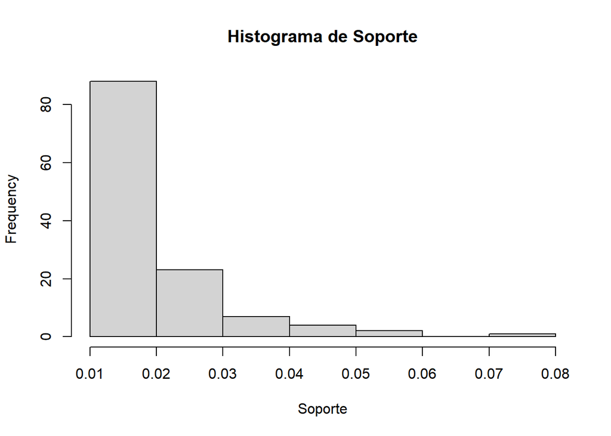

```r
# RESPUESTA

hist(rules.sorted@quality$support, main = "Histograma de Soporte", xlab = "Soporte")
```

**R:** Podemos notar que los soportes con mayor frecuencia son los que se encuentran entre 0.01 y 0.02, y que a medida que el soporte aumenta, la frecuencia disminuye. Por lo tanto, se deduce una tendencia a que las reglas tengan un bajo soporte

**1.3** Muestre 10 reglas de asociación que más podrían ayudar a un supermercado a crear recomendaciones de productos. Emplee *Apriori* con `confidence=0.3` y que la regla aparezca en al menos un 2% del dataset. Fundamente su respuesta en base a los resultados.

```r
# RESPUESTA
rules2 <- apriori(Groceries, parameter = list(support = 0.02, confidence = 0.3))
```

```
## Apriori
##
## Parameter specification:
##  confidence minval smax arem  aval originalSupport maxtime support minlen
##         0.3    0.1    1 none FALSE            TRUE       5    0.02      1
##  maxlen target  ext
##      10  rules TRUE
##
## Algorithmic control:
##  filter tree heap memopt load sort verbose
##     0.1 TRUE TRUE  FALSE TRUE    2    TRUE
##
## Absolute minimum support count: 196
##
## set item appearances ...[0 item(s)] done [0.00s].
## set transactions ...[169 item(s), 9835 transaction(s)] done [0.00s].
## sorting and recoding items ... [59 item(s)] done [0.00s].
## creating transaction tree ... done [0.00s].
## checking subsets of size 1 2 3 done [0.00s].
## writing ... [37 rule(s)] done [0.00s].
## creating S4 object  ... done [0.00s].
```

```r
rules2.sorted <- sort(rules2, by = "lift")
inspect(head(rules2.sorted, 10))
```

```
##      lhs                                    rhs                support
## [1]  {other vegetables, whole milk}      => {root vegetables}  0.02318251
## [2]  {root vegetables, whole milk}       => {other vegetables} 0.02318251
## [3]  {root vegetables}                   => {other vegetables} 0.04738180
## [4]  {whipped/sour cream}                => {other vegetables} 0.02887646
## [5]  {whole milk, yogurt}                => {other vegetables} 0.02226741
## [6]  {other vegetables, yogurt}          => {whole milk}       0.02226741
## [7]  {butter}                            => {whole milk}       0.02755465
## [8]  {pork}                              => {other vegetables} 0.02165735
## [9]  {curd}                              => {whole milk}       0.02613116
## [10] {root vegetables, other vegetables} => {whole milk}       0.02318251
##      confidence coverage   lift     count
## [1]  0.3097826  0.07483477 2.842082 228
## [2]  0.4740125  0.04890696 2.449770 228
## [3]  0.4347015  0.10899847 2.246605 466
## [4]  0.4028369  0.07168277 2.081924 284
## [5]  0.3974592  0.05602440 2.054131 219
## [6]  0.5128806  0.04341637 2.007235 219
## [7]  0.4972477  0.05541434 1.946053 271
## [8]  0.3756614  0.05765125 1.941476 213
## [9]  0.4904580  0.05327911 1.919481 257
## [10] 0.4892704  0.04738180 1.914833 228
```

Por definicion de probabilidad, lift nos da una medida de la certeza de que se compre Y dado que se compra X, lo cual es precisamente lo que más le podría ayuda al supermercado (comercialmente), pues tiene mayor caracter predictivo.

Notamos que el lift es mayor a 1, lo que nos indica que las reglas mostradas estan *positivamente correlacionadas*. Adicionalmente, notemos que los productos consecuentes son todos vegetales o leche entera.

**1.4** Ocupando las reglas de la pregunta anterior obtenga el lift mas bajo ¿Qué puede concluir con respecto a la relacion de los antecendente y consecuentes de estas reglas? ¿Que significa esto en terminos de grupos de productos?

```r
# RESPUESTA

rules2_dec <- rules2
rules2_dec <- sort(rules2_dec, by = "lift", decreasing = FALSE)
inspect(head(rules2_dec, 1))
```

```
##     lhs             rhs          support    confidence coverage  lift     count
## [1] {rolls/buns} => {whole milk} 0.05663447 0.3079049  0.1839349 1.205032 557
```

**R:** Notamos que el lift mas bajo sigue siendo un valor mayor a 1. Esto nos dice que **todas** las reglas obtenidas tienen un lift mayor a 1, luego la relacion de los antecedentes y consecuentes de estas reglas es de una correlación positiva. En términos de productos, podemos concluir que llevar un producto del antecedente aumenta la probabilidad de llevar un producto del consecuente, y que al comprar es probable que se lleve whole milk.

**1.5** El siguiente gráfico muestra las reglas obtenidas con Apriori con minsup=0.01 y minconf=0.1. Describa tres observaciones a partir del gráfico (por ejemplo: “la mayoría de las reglas tienen soporte menor a 0.05”).

```r
rules <- apriori(Groceries, parameter=list(support=0.01, confidence=0.1))
```

```
## Apriori
##
## Parameter specification:
##  confidence minval smax arem  aval originalSupport maxtime support minlen
##         0.1    0.1    1 none FALSE            TRUE       5    0.01      1
##  maxlen target  ext
##      10  rules TRUE
##
## Algorithmic control:
##  filter tree heap memopt load sort verbose
##     0.1 TRUE TRUE  FALSE TRUE    2    TRUE
##
## Absolute minimum support count: 98
##
## set item appearances ...[0 item(s)] done [0.00s].
## set transactions ...[169 item(s), 9835 transaction(s)] done [0.00s].
## sorting and recoding items ... [88 item(s)] done [0.00s].
## creating transaction tree ... done [0.00s].
## checking subsets of size 1 2 3 4 done [0.00s].
## writing ... [435 rule(s)] done [0.00s].
## creating S4 object  ... done [0.00s].
```

```
## To reduce overplotting, jitter is added! Use jitter = 0 to prevent jitter.
```

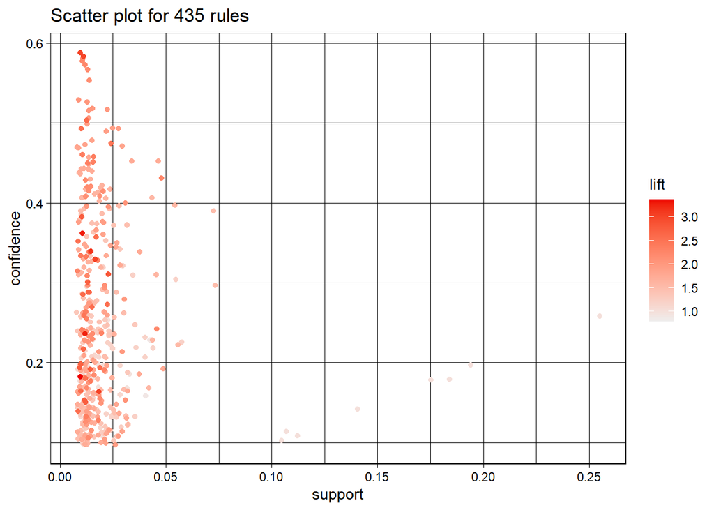

```r
plot(rules)
```

**R:** 1. La mayoría de las reglas tienen soporte menor a 0.05

2. La mayoría de las reglas tienen confianza menor a 0.5
3. La mayoría de las reglas tienen lift menor a 2